# 條狀圖 (Bar Plots)

Tony Chuo, NSYSU

2022-03-19 15:34:57

### 1. 三種不一樣的條狀圖

##### 1.1 準備資料

載入 libraries，並預設繪圖參數

```r
pacman::p_load(dplyr,ggplot2,plotly,gridExtra)
theme_set(theme_get() + theme(
  text=element_text(size=8), legend.key.size=unit(10,"points")
  ))
```

載入 comics 資料集

```r
D = read.csv("data/comics1.csv",stringsAsFactors=F) %>% as_tibble
glimpse(D)
```

```
Rows: 7,250
Columns: 9
$ publisher   <chr> "dc", "dc", "dc", "dc", "dc", "dc", "dc", "dc", "dc", "dc"~
$ name        <chr> "Batman (Bruce Wayne)", "Superman (Clark Kent)", "Green La~
$ align       <chr> "Good", "Good", "Good", "Good", "Good", "Good", "Good", "G~
$ eye         <chr> "Blue", "Blue", "Brown", "Brown", "Blue", "Blue", "Blue", ~
$ hair        <chr> "Black", "Black", "Brown", "White", "Black", "Black", "Blo~
$ sex         <chr> "Male", "Male", "Male", "Male", "Male", "Female", "Male", ~
$ alive       <chr> "Living", "Living", "Living", "Living", "Living", "Living"~
$ appearances <int> 3093, 2496, 1565, 1316, 1237, 1231, 1121, 1095, 1075, 1028~
$ year        <int> 1939, 1986, 1959, 1987, 1940, 1941, 1941, 1989, 1969, 1956~
```

`tibble` 在 `dplyr` 中，被定義為增強型的資料框。

##### 1.2 三種條狀圖

🌻 `ggplot`之中，有三種條狀圖可以使用

- **geom_histogram** 顯示連續變數的 *分布*。
- **geom_bar** 顯示離散變數 的*計數* (*分布*)
- **geom_col** 顯示 / 比較 不同類別間的統計數據。

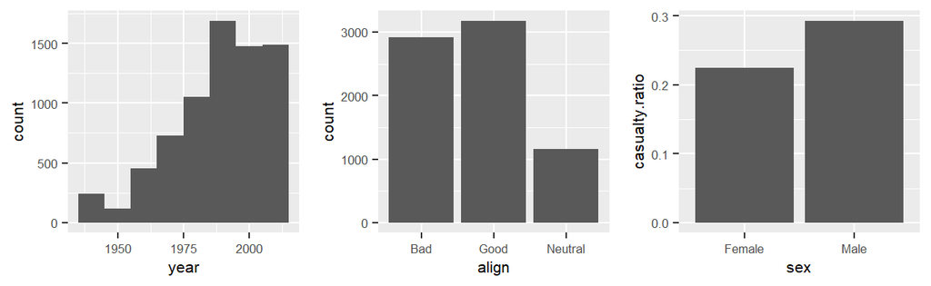

```r
g1 = ggplot(D, aes(x=year)) + geom_histogram(binwidth=10)
g2 = ggplot(D, aes(x=align)) + geom_bar()
g3 = group_by(D, sex) %>%
  summarise( casualty.ratio = mean(alive=="Deceased") ) %>%
  ggplot(aes(x=sex, y=casualty.ratio)) + geom_col()
grid.arrange(g1,g2,g3,nrow=1)  # align three plots in a row
```

```r
#geom_col() 要自己算(選)Y，其他的會自動算成數量
```

🌻 這些條狀圖有助於我們做分類比較

- 幾十年來，新角色的數量
- 好人、壞人，以及中立角色的數量
- 男性角色和女性角色平均的傷亡率

### 2. 兩類別、大類與細類比較

只要在`aes()`之中將`fill`屬性對應到細類變數， 我們就可以在條狀圖的大類之中，以顏色區分細類。

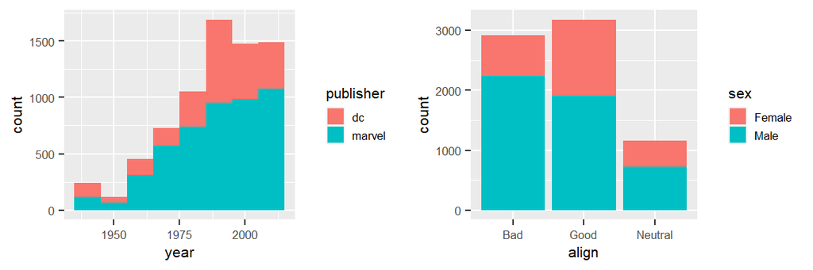

```r
g1 = ggplot(D, aes(x=year, fill=publisher)) + geom_histogram(binwidth=10)
g2 = ggplot(D, aes(x=align, fill=sex)) + geom_bar()
grid.arrange(g1,g2,nrow=1)  # align three plots in a row
```

**🚴 **EXERCISE :****

請試著修改以下程式碼來製作下面的圖表。

```r
# group_by(D, sex) %>%
#  summarise( casualty.ratio = mean(alive=="Deceased") ) %>%
#  ggplot(aes(x=sex, y=casualty.ratio)) + geom_col()
```

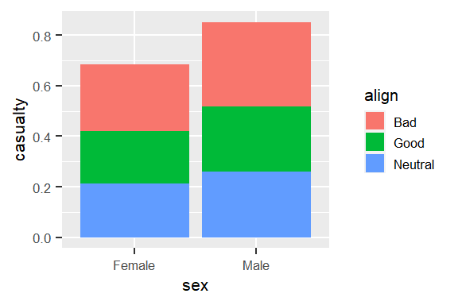

```r
group_by(D, sex, align) %>%
  summarise(casualty=mean(alive=="Deceased"), .groups="drop") %>%
  ggplot(aes(x=sex, y=casualty, fill=align)) + geom_col()
```

[output not shown]

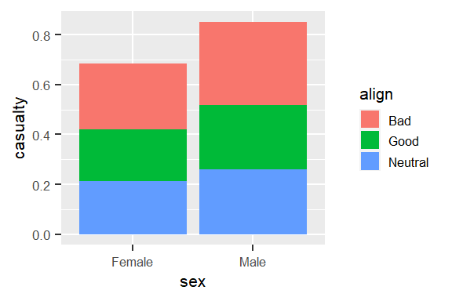

```r
group_by(D, sex, align) %>%
  summarise(casualty=mean(alive=="Deceased")) %>%
  ggplot(aes(x=sex, y=casualty, fill=align)) + geom_col()
```

**❓ **QUIZ :****

根據以上圖表

- 你知道哪個性別有較多的「好人」角色嗎？
- 「男性中立角色要比女性中立角色來得多」，這句話是公平的嗎？

### 3. 比較的基礎

##### 3.1 列聯表 (Contingency Table)

類別間的比較是基於一種名為 列聯表 的資料結構。

```r
table(D$align, D$sex)
```

```
          Female Male
  Bad        676 2239
  Good      1264 1914
  Neutral    432  725
```

##### 3.2 列聯表的長型資料格式

然而，`ggplot` 並不採用表格型式。 為了和 `aes()` 這一配對繪圖相容， 我們需要準備 長型資料格式 的數據。

在製作長型資料格式時，`count()` 比 `group_by() %>% summarise()` 更容易操作。

```r
count(D, align, sex)
```

```
# A tibble: 6 x 3
  align   sex        n
  <chr>   <chr>  <int>
1 Bad     Female   676
2 Bad     Male    2239
3 Good    Female  1264
4 Good    Male    1914
5 Neutral Female   432
6 Neutral Male     725
```

##### 3.3 設置 `position` 來改變比較的基礎

透過在 geom_col() 中設置 `position` 這一參數，我們可以用不同方式排列和比較表格中的數據。

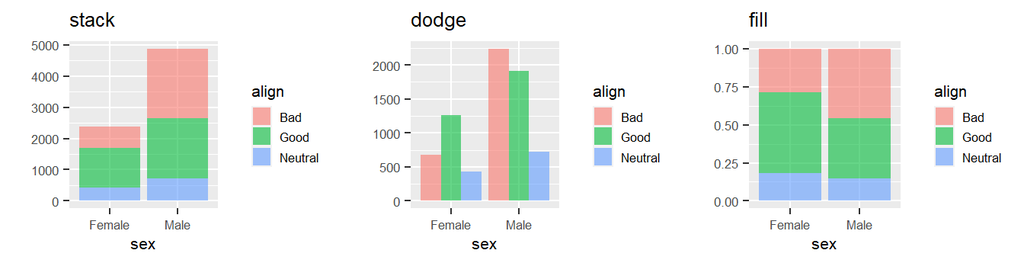

```r
dx = count(D, align, sex)
gg = lapply(c("stack","dodge","fill"), function(pos) {
  ggplot(dx, aes(sex,n,fill=align)) +
    geom_col(position=pos, alpha=0.6) + labs(title=pos,y="")
  })
grid.arrange(grobs=gg, nrow=1)
```

🌻 不同的圖表有不同的用途…

- `stack` 該數據強調性別的總合
- `dodge` 比較表格中所有的數據
- `fill` 將數據轉換為比例，以進行相對性的比較

**❓ **QUIZ :****  
上述三個圖表中，哪個比較容易…

- 依照性別分類，比較「中立」角色的數量
- 依照性別分類，比較「中立」角色的比例
- 比較各性別的總人數

**🚴 **EXERCISE :****  
事實上，我們可以用完全相同的數據再繪製三個圖表。 請試著修改以下程式碼來製作下面的圖表。

```r
# gg = lapply(c("stack","dodge","fill"), function(pos) {
#   ggplot(dx, aes(sex,n,fill=align)) +
#     geom_col(position=pos, alpha=0.6) + labs(title=pos,y="")
#   })
# grid.arrange(grobs=gg, nrow=1)
```

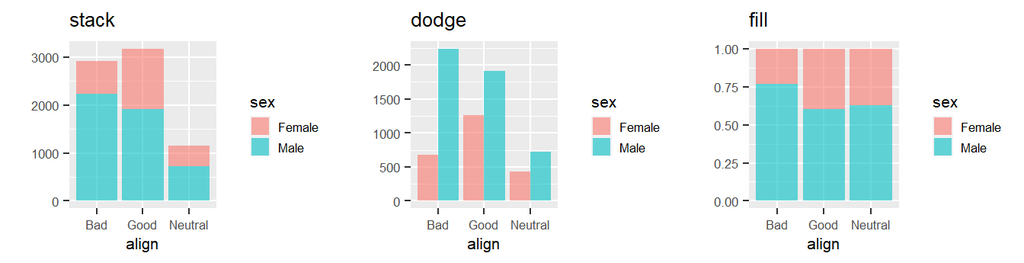

```r
gg = lapply(c("stack","dodge","fill"), function(pos) {
  ggplot(dx, aes(align,n,fill=sex)) +
    geom_col(position=pos, alpha=0.6) + labs(title=pos,y="")
  })
grid.arrange(grobs=gg, nrow=1)
```

### 4. 條形圖的分析能力

讓我們在 `D` 資料集中，新增一個名為 `decade` 的欄位。

```r
D = mutate(D, decade = (D$year -1900) %/% 10)
table(D$decade)
```

```
   3    4    5    6    7    8    9   10   11
  28  271  106  678  823 1304 1581 1803  656
```

##### 4.1 窗格功能 `facet`

好壞人的數量如何隨年代而變 ❓ 好壞人數量的變化趨勢是否因性別、出版商而異 ❓

`facet_grid(var1~var2)`可以就每一種(`v1`,`v2`)的組合畫一個窗格

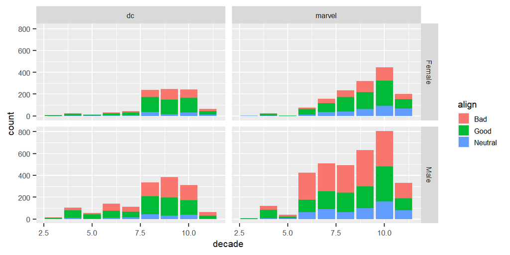

```r
ggplot(D, aes(x=decade, fill=align)) +
  geom_bar() + facet_grid(sex~publisher)
```

我們用兩行簡單的程式碼就可以回答這些看似複雜繁瑣的問題了！

通常，比例會比數量更能反映出趨勢，欲把數字轉換為比例， 我們只需要將 `position='fill` 放在 `geom_bar()` 中。

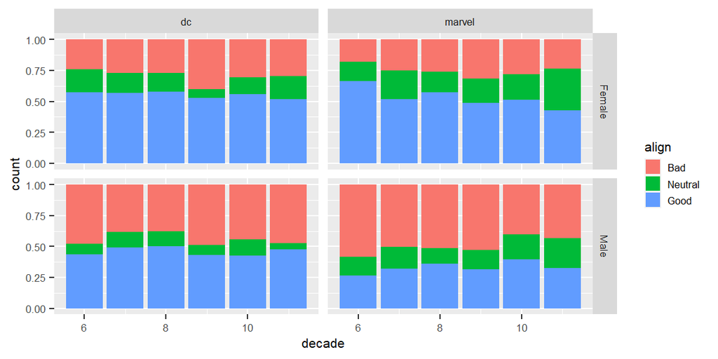

```r
# here we convert `align` into a factor so we can
# re-order the align levels in a desirable way
D2 = D %>% mutate(
  align=factor(align,levels=c("Bad","Neutral","Good"))
  ) %>%
  filter(decade >= 6)
ggplot(D2, aes(x=decade, fill=align)) +
  geom_bar(position="fill") +
  facet_grid(sex~publisher)
```

##### 4.2 比例 vs. 數量

下面是一個條形圖，顯示了在不同頭髮顏色和不同眼睛顏色的搭配中，好人和壞人所佔的比例。

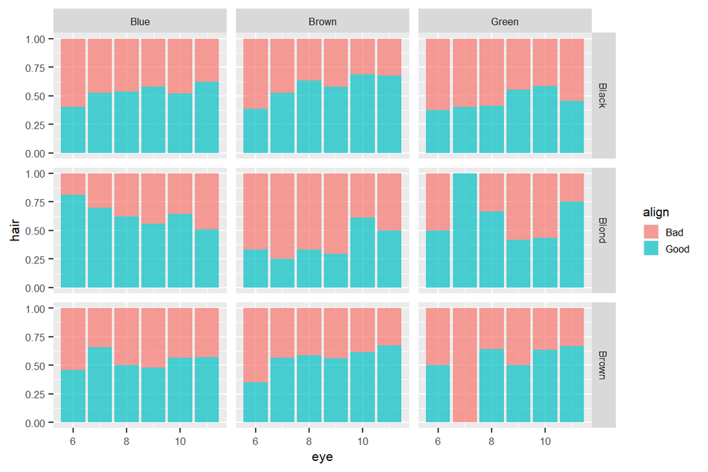

```r
hx = count(D2, hair, sort=T)
ex = count(D2, eye, sort=T)
D2 %>% filter(
  hair%in%hx$hair[1:3], eye%in%ex$eye[1:3],
  align!="Neutral") %>%
  ggplot(aes(decade,fill=align)) +
  geom_bar(position="fill",alpha=0.7) +
  labs(x="eye",y="hair") +
  facet_grid(hair~eye)
```

**🚴 **EXERCISE :****  
你可以試著修改上面的程式碼

- 繪製**數字**而不是**比率**嗎？
- 你發現了什麼呢？
- 在這個 exercise 中，你學到了什麼呢？